# 36-315 Lab 09

Eu Jing Chua

eujingc

Style guide: Tidyverse styleguide

Collaborators: NIL

Due Friday, Nov 15, 2019 (6:30pm) on Canvas

# Problem 1

## a.

There are 16 columns and 4359 rows. the earliest trip date is 2016-06-01, and the latest is 2016-06-30

```r
# Only use the June 2016 subset
bike <- read_csv("http://stat.cmu.edu/315/data/nyc-citi-bike-subset.csv")

# Add start_date variable
bike <- mutate(bike,
               start_date = as.Date(starttime, format = "%m/%d/%y"))

dim(bike)
```

```
## [1] 4359   16
```

```r
summary(bike$start_date)
```

```
##         Min.      1st Qu.       Median         Mean      3rd Qu.
## "2016-06-01" "2016-06-09" "2016-06-17" "2016-06-15" "2016-06-23"
##         Max.
## "2016-06-30"
```

## b.

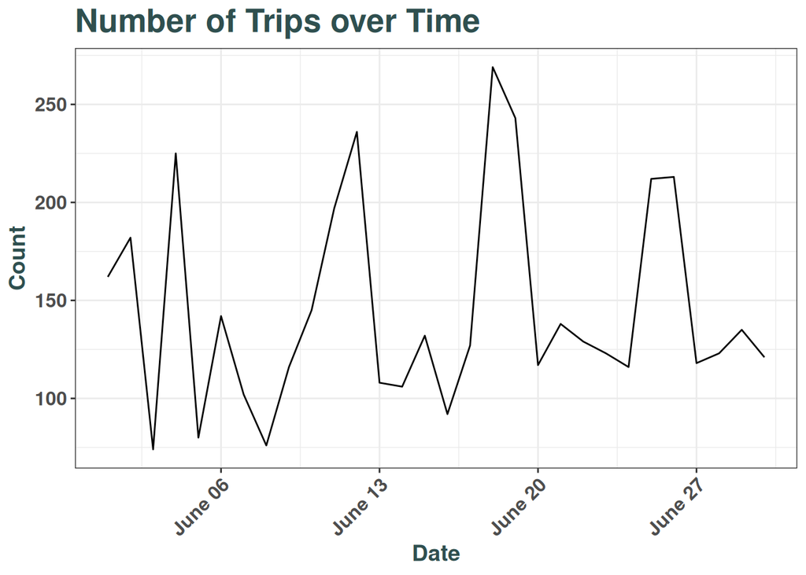

```r
#  Summarize bike, creating a new data.frame that includes the number
#  of trips taken on each day

trips_per_day <- bike %>%
  group_by(start_date) %>%
  summarize(n_trips = n())

#  Create a time series plot with the dates on the x-axis and the number of
#  trips per day on the y-axis

ggplot(trips_per_day, aes(x = start_date, y = n_trips)) +
  geom_line() +
  scale_x_date(date_breaks = "1 week", date_labels = "%B %d") +
  labs(x = "Date", y = "Count",
       title = "Number of Trips over Time") +
    eujingc_315_theme +
    theme(axis.text.x = element_text(angle = 45, hjust = 1))
```

## c.

We can see more variability in customers compared to subcribers. This makes sense as subcribers would more consistently use the service in comparison to one-off customers.

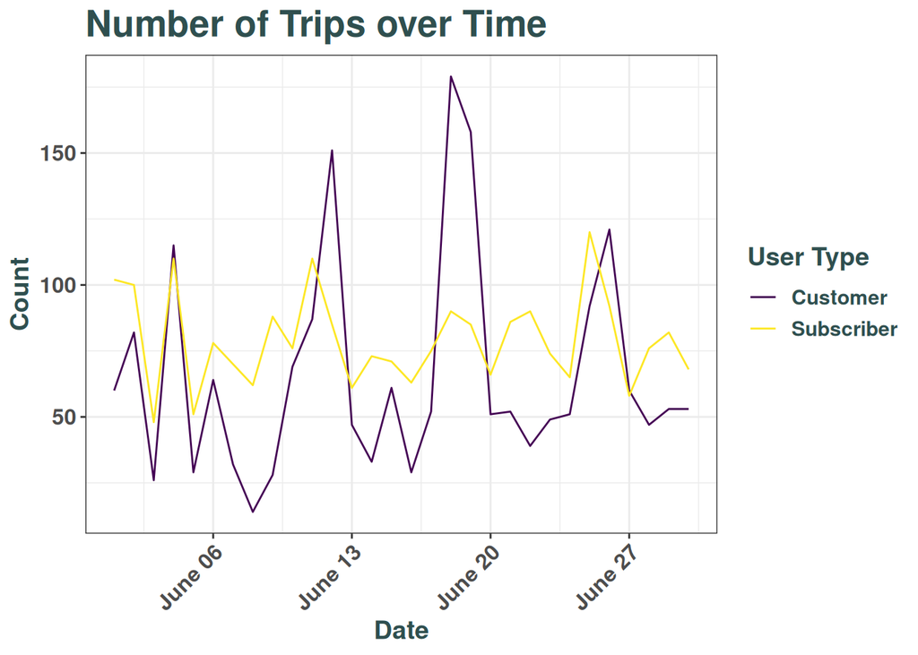

```r
#  Summarize bike, creating a new data.frame that includes the number
#  of trips taken on each day, split by usertype

trips_per_day_usertype <- bike %>%
  group_by(start_date, usertype) %>%
  summarize(n_trips = n())

#  Create a time series plot with the dates on the x-axis and the number of
#  trips per day on the y-axis, split by usertype

ggplot(trips_per_day_usertype,
       aes(x = start_date, y = n_trips, color = usertype)) +
  geom_line() +
  scale_x_date(date_breaks = "1 week", date_labels = "%B %d") +
  labs(x = "Date", y = "Count", color = "User Type",
       title = "Number of Trips over Time") +
    scale_color_viridis(discrete = TRUE) +
    eujingc_315_theme +
    theme(axis.text.x = element_text(angle = 45, hjust = 1))
```

## d.

We can see that the customer’s moving average still has higher variation than the suscriber’s.

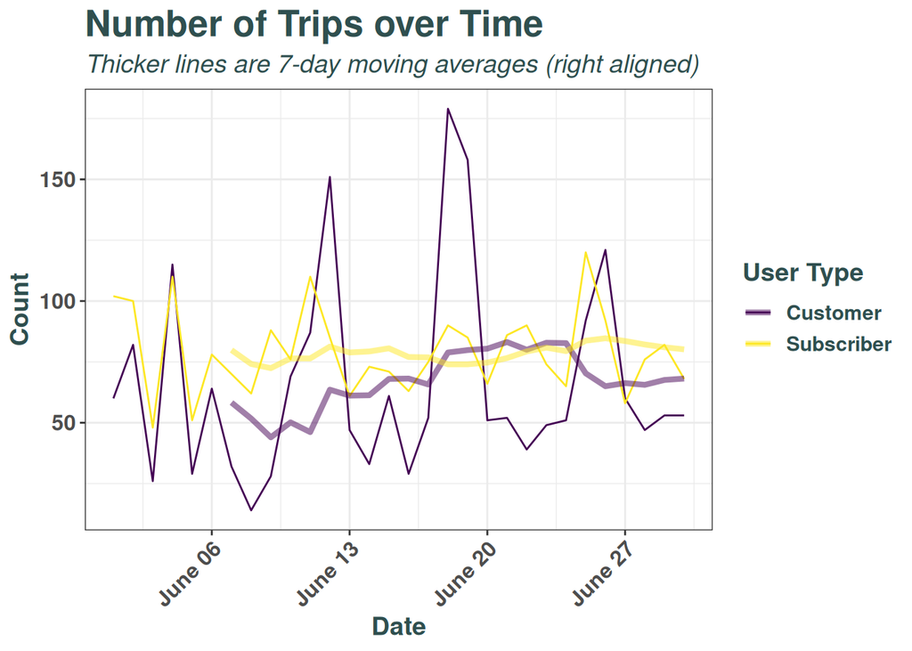

```r
library(ggseas)

ggplot(trips_per_day_usertype,
       aes(x = start_date, y = n_trips,
           color = usertype)) +
  geom_line() +
  stat_rollapplyr(align = "right", FUN = mean,
                  width = 7, size = 1.5, alpha = 0.5) +
  scale_x_date(date_breaks = "1 week", date_labels = "%B %d") +
  labs(x = "Date", y = "Count", color = "User Type",
       title = "Number of Trips over Time",
       subtitle = "Thicker lines are 7-day moving averages (right aligned)") +
    scale_color_viridis(discrete = TRUE) +
    eujingc_315_theme +
    theme(axis.text.x = element_text(angle = 45, hjust = 1))
```

# Problem 2

## a.

Most of the autocorrelations are near zero, except for lag 0. This makes sense as at lag 0, we are calculating the correlation of a random variable with exactly itself, which should always be 1.

```r
rand_ts <- rnorm(1000)
acf(rand_ts, plot = FALSE)
```

```
##
## Autocorrelations of series 'rand_ts', by lag
##
##      0      1      2      3      4      5      6      7      8      9
##  1.000  0.034  0.079 -0.007  0.034 -0.044  0.026 -0.012 -0.056  0.010
##     10     11     12     13     14     15     16     17     18     19
##  0.005  0.007 -0.047  0.052 -0.031  0.054 -0.029 -0.022  0.034 -0.033
##     20     21     22     23     24     25     26     27     28     29
## -0.049 -0.080  0.025 -0.024  0.045 -0.012  0.011 -0.005  0.016  0.016
##     30
##  0.019
```

## b.

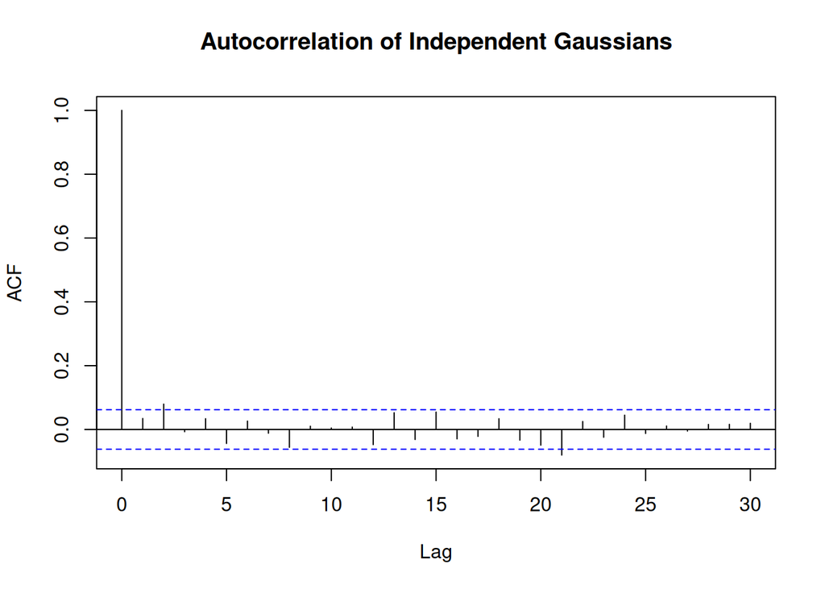

```r
acf(rand_ts, plot = TRUE, main = "Autocorrelation of Independent Gaussians")
```

## c.

```r
bike_customer_acf <- acf(filter(trips_per_day_usertype,
                                usertype == "Customer")$n_trips,
                         plot = FALSE)

bike_subscriber_acf <- acf(filter(trips_per_day_usertype,
                                 usertype == "Subscriber")$n_trips,
                          plot = FALSE)
```

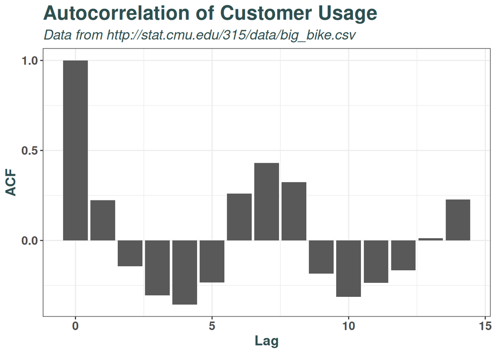

```r
bike_customer_acf_df <- data.frame(lag = bike_customer_acf$lag,
                                   acf = bike_customer_acf$acf)
ggplot(bike_customer_acf_df, aes(x = lag, y = acf)) +
  geom_col() +
  labs(title = "Autocorrelation of Customer Usage",
       subtitle = "Data from http://stat.cmu.edu/315/data/big_bike.csv",
       x = "Lag", y = "ACF") +
    eujingc_315_theme
```

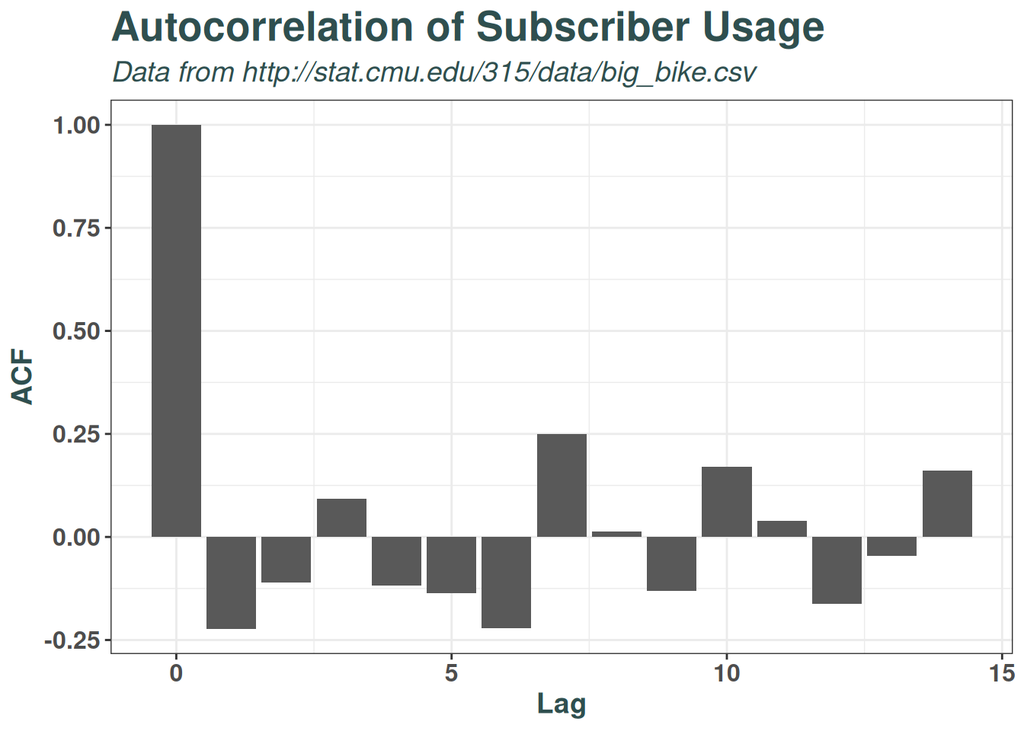

```r
bike_subscriber_acf_df <- data.frame(lag = bike_subscriber_acf$lag,
                                   acf = bike_subscriber_acf$acf)
ggplot(bike_subscriber_acf_df, aes(x = lag, y = acf)) +
  geom_col() +
  labs(title = "Autocorrelation of Subscriber Usage",
       subtitle = "Data from http://stat.cmu.edu/315/data/big_bike.csv",
       x = "Lag", y = "ACF") +
    eujingc_315_theme
```

Seeing that the greatest correlation is at 7 days lag, this indicates a seasonal pattern across weeks where the same day of the week tends to have similar counts, which makes sense as people tend to have weekly schedules.

# Problem 3

## a.

The latitude is 40.4442526, and the longitude is -79.955433.

## b.

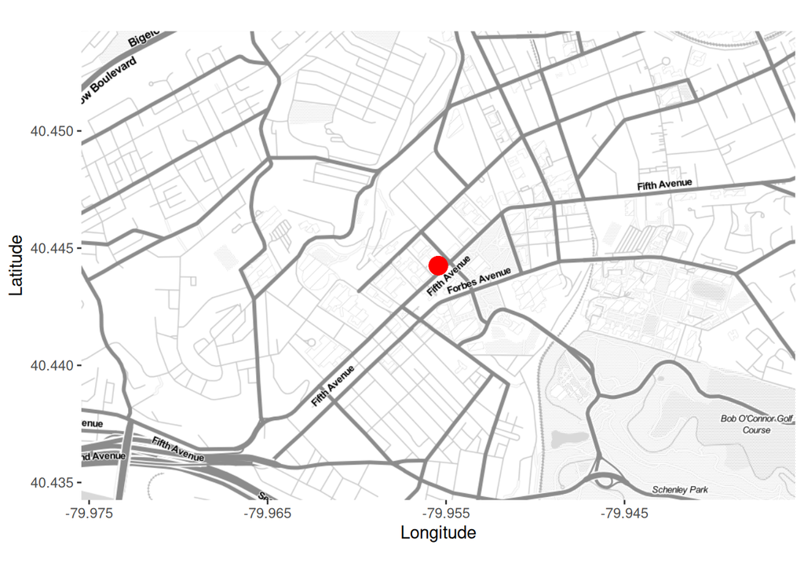

```r
cat_long <- -79.955433
cat_lat <- 40.4442526
catlearn <- c(left = cat_long - 0.02, bottom = cat_lat - 0.01,
          right = cat_long + 0.02, top = cat_lat + 0.01)

map_base <- get_stamenmap(catlearn, maptype = "toner-lite", zoom = 15)

map_object <- ggmap(map_base, extent = "device")

map_object2 <- ggmap(map_base) +
  geom_point(x = cat_long, y = cat_lat, color = "red", size = 5) +
  labs(x = "Longitude", y = "Latitude")

map_object2
```

## c.

```r
#  Load and format airports data
airports <- read_csv("https://raw.githubusercontent.com/jpatokal/openflights/master/data/airports.dat",
                     col_names = c("ID", "name", "city", "country", "IATA_FAA",
                                   "ICAO", "lat", "lon", "altitude", "timezone",
                                   "DST"))

#  Load and format routes data
routes <- read_csv("https://raw.githubusercontent.com/jpatokal/openflights/master/data/routes.dat",
                   col_names = c("airline", "airlineID", "sourceAirport",
                                 "sourceAirportID", "destinationAirport",
                                 "destinationAirportID", "codeshare", "stops",
                                 "equipment")) %>%
  filter(sourceAirportID != "\\N",
         destinationAirportID != "\\N") %>%
  mutate(sourceAirportID = as.integer(sourceAirportID),
         destinationAirportID = as.integer(destinationAirportID))

#  Manipulate the routes data to create two new data.frames
#    one for arrivals, one for departures.
#  Each counts the number of flights arriving/departing from each airport.
departures <- routes %>%
  group_by(sourceAirportID) %>%
  summarise(flights = n())

arrivals <- routes %>%
  group_by(destinationAirportID) %>%
  summarise(flights = n())

#  Merge each of the arrivals/departures data.frames with the airports data.frame above
airportD <- left_join(airports, departures, by = c("ID" = "sourceAirportID"))
airportA <- left_join(airports, arrivals, by = c("ID" = "destinationAirportID"))

#  Create data.frame of routes to/from a specific city
my_airport_code <- "PIT"

my_routes <- routes %>% filter(sourceAirport == my_airport_code |
                               destinationAirport == my_airport_code)

#  Add in relevant information from the airports data.frame
#  Do this in two steps, so that you first pull in the source airport information
#  and then pull in the destination airport information
#  This can be done easily with two calls to left_join()
#  The rest of the code is just formatting
my_airport_data <- my_routes %>%
  left_join(airports, by = c("sourceAirport" = "IATA_FAA")) %>%
  dplyr::select(destinationAirport, lat, lon, timezone) %>%
  rename(source_lat = lat, source_lon = lon, source_timezone = timezone) %>%
  left_join(airports, by = c("destinationAirport" = "IATA_FAA")) %>%
  dplyr::select(source_lat, source_lon, source_timezone, lat, lon, timezone) %>%
  rename(dest_lat = lat, dest_lon = lon, dest_timezone = timezone)
```

## d.

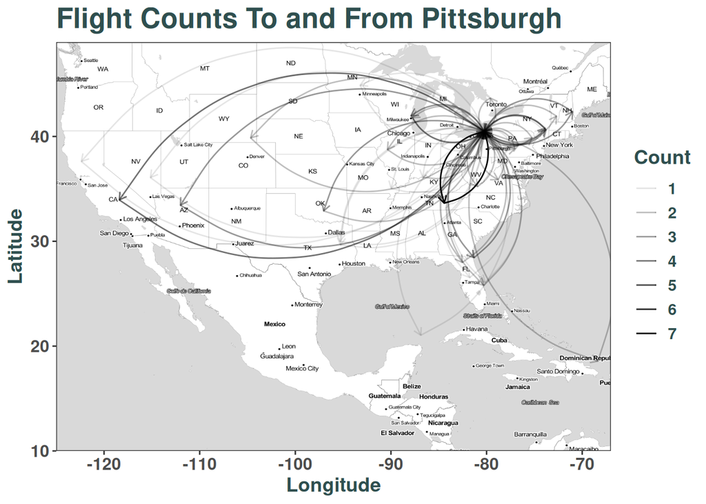

```r
US <- c(left = -125, bottom = 10, right = -67, top = 49)
map <- get_stamenmap(US, zoom = 5, maptype = "toner-lite")

airport_counts <- my_airport_data %>%
    group_by(source_lat, source_lon, dest_lat, dest_lon) %>%
    summarize(count = n())

ggmap(map, extent = "device") +
    geom_curve(aes(x = source_lon, y = source_lat,
                   xend = dest_lon, yend = dest_lat,
                   alpha = count),
               arrow = arrow(length = unit(0.02, "npc")),
               data = airport_counts) +
    coord_cartesian() +
    labs(x = "Longitude", y = "Latitude",
         title = "Flight Counts To and From Pittsburgh",
         alpha = "Count") +
    eujingc_315_theme
```